# Individual Project 3

# Report

## Part 1: Summary

```
dat

 24  Variables      200000  Observations
--------------------------------------------------------------------------------
id
       n  missing distinct     Info     Mean      Gmd      .05      .10
   2e+05        0    10000        1     5000     3333      501     1001
     .25      .50      .75      .90      .95
    2501     5000     7500     9000     9500

lowest :     1     2     3     4     5, highest:  9996  9997  9998  9999 10000
--------------------------------------------------------------------------------
Age
       n  missing distinct     Info     Mean      Gmd      .05      .10
   2e+05        0       55        1    45.03    18.39       20       23
     .25      .50      .75      .90      .95
      31       45       59       67       70

lowest : 18 19 20 21 22, highest: 68 69 70 71 72
--------------------------------------------------------------------------------
Gender
       n  missing distinct
   2e+05    0e+00    2e+00

Value      Female   Male
Frequency  106720  93280
Proportion  0.534  0.466
--------------------------------------------------------------------------------
Income
       n  missing distinct     Info     Mean      Gmd      .05      .10
   2e+05        0      182        1    80474    46676    29000    33000
     .25      .50      .75      .90      .95
   43000    76000   114000   143000   161000

lowest :   7000   9000  10000  11000  12000, highest: 185000 186000 187000 193000 197000
--------------------------------------------------------------------------------
Region
       n  missing distinct
   2e+05    0e+00    4e+00

```

[output cut: 184 more lines]

```
   16484   183516       11    0.974    5.288    2.196        2        3
     .25      .50      .75      .90      .95
       4        5        7        8        9

lowest :  0  1  2  3  4, highest:  6  7  8  9 10

Value          0     1     2     3     4     5     6     7     8     9    10
Frequency    317   301   592  1371  2881  3762  2911  2104  1405   595   245
Proportion 0.019 0.018 0.036 0.083 0.175 0.228 0.177 0.128 0.085 0.036 0.015
--------------------------------------------------------------------------------
Advocacy
       n  missing distinct     Info      Sum     Mean      Gmd
   16484   183516        2    0.655    11176    0.678   0.4367

--------------------------------------------------------------------------------
```

## Part 2: Specific Questions

### Q1: Respondent Variables

#### Age Group

```
x
18-34 35-49 50-64   65+
 31.1  26.9  27.1  14.9
```

#### Gender

```
x
Female   Male
  53.4   46.6
```

#### Income Group

```
x
under 50K   50K-75K  75K-100K 100K-150K     150K+
     32.7      15.5      21.2      22.0       8.6
```

#### Region

```
x
  Midwest Northeast     South      West
     26.2      25.6      24.1      24.1
```

#### Persona

```
x
     Ambivalent Adventurer     Consistent Compromiser
                      24.5                       17.2
   Materialistic Meditator        Outdoorsy Ombudsman
                      11.5                       14.1
  Precociously Preoccupied Technological Triumphalist
                       9.3                       23.4
```

### Q2: Segmented Outcomes

#### Part A

What are the top 5 products by Awareness rates in the Northeast?

```
         Product tot_awareness
1:  Maybe Mobile      84.73849
2: Mobile Mayhem      79.03981
3:     Next Text      73.77049
4:       App Map      72.87276
5:      Buzzdial      71.03825
```

#### Part B

What are the top 5 products by Advocacy rates among females who earn at least $100,000?

```
           Product tot_advocacy
1: Communic Nation    100.00000
2:    Smartophonic     87.80161
3:   Mobile Mayhem     85.24590
4:       Next Text     85.16484
5:      Triumphone     77.77778
```

### Q3: Overall Brand Perceptions

What are the top 5 brands by the overall average perception?

```
        Product OverallAveragePerception
1:      Screenz                 7.207686
2:  Cellularity                 6.389792
3:    Next Text                 6.329150
4:   No Buttons                 6.235283
5: Smartophonic                 6.102885
```

### Q4: Gaps in Outcomes

#### Part A

Which 5 products have the largest gap between the rate of consumption and the rate of awareness?

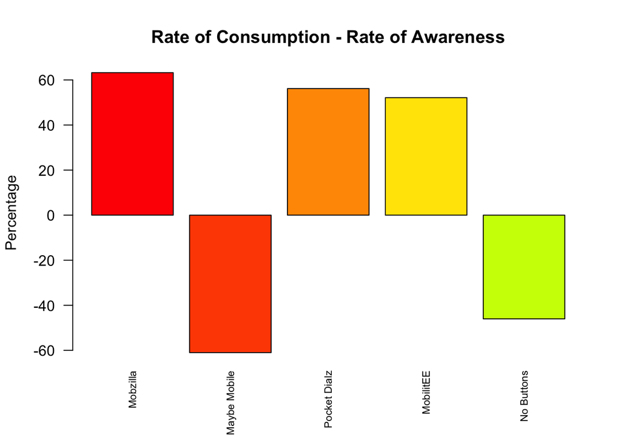

#### Part B

Which 5 products have the largest gap between the rate of Awareness and the average Satisfaction?

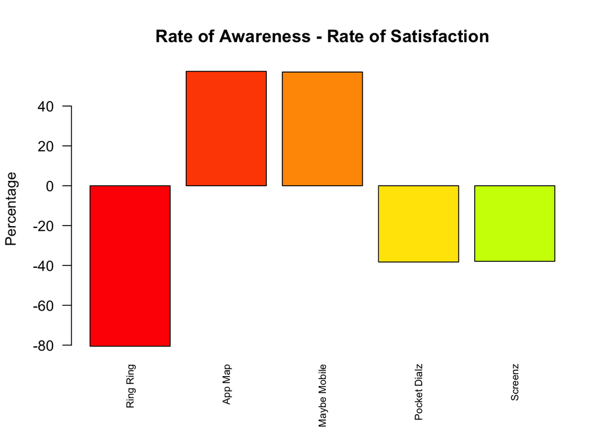

### Q5: Aggregated Engagement

#### Part A

How much impact does respondent’s overall trends in awareness have for that person’s awareness with Buzzdial phones?

```
                                            OR        2.5 %       97.5 %
(Intercept)                       1.363643e+00 1.067619e+00 1.742219e+00
AgeGroups35-49                    1.809087e+00 1.620068e+00 2.021062e+00
AgeGroups50-64                    8.782966e-01 7.907709e-01 9.754754e-01
AgeGroups65+                      1.274824e+00 1.121525e+00 1.449893e+00
GenderMale                        8.635626e-01 7.951507e-01 9.378365e-01
IncomeGroup50K-75K                9.193014e-01 8.104909e-01 1.043032e+00
IncomeGroup75K-100K               9.707809e-01 8.658102e-01 1.088671e+00
IncomeGroup100K-150K              9.268414e-01 8.277761e-01 1.037887e+00
IncomeGroup150K+                  8.802673e-01 7.531915e-01 1.029519e+00
RegionNortheast                   2.034734e+00 1.811710e+00 2.286327e+00
RegionSouth                       1.041337e+00 9.302824e-01 1.165699e+00
RegionWest                        1.299469e+00 1.159443e+00 1.456670e+00
PersonaConsistent Compromiser     8.035652e-01 7.070364e-01 9.132639e-01
PersonaMaterialistic Meditator    9.784798e-01 8.451032e-01 1.133478e+00
PersonaOutdoorsy Ombudsman        9.732242e-01 8.487184e-01 1.116342e+00
PersonaPrecociously Preoccupied   9.987684e-01 8.530158e-01 1.170330e+00
PersonaTechnological Triumphalist 1.059178e+00 9.401900e-01 1.193297e+00
AggregatedEngagement              7.645848e-01 4.950048e-01 1.180853e+00
                                        pvalue
(Intercept)                       1.303355e-02
AgeGroups35-49                    7.889734e-26
AgeGroups50-64                    1.537361e-02
AgeGroups65+                      2.098689e-04
GenderMale                        4.937308e-04
IncomeGroup50K-75K                1.909708e-01
IncomeGroup75K-100K               6.117678e-01
IncomeGroup100K-150K              1.879467e-01
IncomeGroup150K+                  1.096097e-01
RegionNortheast                   5.181911e-33
RegionSouth                       4.815047e-01
RegionWest                        6.800586e-06
PersonaConsistent Compromiser     8.086858e-04
PersonaMaterialistic Meditator    7.714206e-01
PersonaOutdoorsy Ombudsman        6.978584e-01
PersonaPrecociously Preoccupied   9.878105e-01
PersonaTechnological Triumphalist 3.444309e-01
AggregatedEngagement              2.261489e-01
```

#### Part B

How much impact does respondent’s overall trends in satisfaction have for that person’s satisfaction with Buzzdial phones?

```
                                  coefficients       2.5 %      97.5 %
(Intercept)                        6.995999604  6.77905783  7.21294137
AgeGroups35-49                     0.447030061  0.33647549  0.55758463
AgeGroups50-64                     0.579222434  0.45684190  0.70160297
AgeGroups65+                       0.644754915  0.49417799  0.79533184
GenderMale                        -0.002618658 -0.09202247  0.08678516
IncomeGroup50K-75K                -0.041399909 -0.17929825  0.09649843
IncomeGroup75K-100K               -0.040312616 -0.16275723  0.08213200
IncomeGroup100K-150K               0.015545122 -0.10773999  0.13883023
IncomeGroup150K+                   0.003699065 -0.17028443  0.17768256
RegionNortheast                   -0.565513490 -0.69468402 -0.43634296
RegionSouth                       -0.500404237 -0.61769499 -0.38311348
RegionWest                        -0.285954160 -0.41841085 -0.15349747
PersonaConsistent Compromiser      1.119881314  0.93765653  1.30210610
PersonaMaterialistic Meditator     0.520428289  0.36645929  0.67439728
PersonaOutdoorsy Ombudsman         0.532017465  0.39039829  0.67363664
PersonaPrecociously Preoccupied   -0.428265674 -0.56167269 -0.29485866
PersonaTechnological Triumphalist  0.459038901  0.32528252  0.59279528
AggregatedEngagement.Satisfaction  0.104984329  0.07234838  0.13762028
                                        pvalue
(Intercept)                       0.000000e+00
AgeGroups35-49                    3.938641e-15
AgeGroups50-64                    4.918599e-20
AgeGroups65+                      9.498943e-17
GenderMale                        9.541942e-01
IncomeGroup50K-75K                5.560438e-01
IncomeGroup75K-100K               5.185312e-01
IncomeGroup100K-150K              8.046971e-01
IncomeGroup150K+                  9.667421e-01
RegionNortheast                   2.003739e-17
RegionSouth                       1.218031e-16
RegionWest                        2.416628e-05
PersonaConsistent Compromiser     3.777759e-32
PersonaMaterialistic Meditator    4.523195e-11
PersonaOutdoorsy Ombudsman        2.699352e-13
PersonaPrecociously Preoccupied   3.879480e-10
PersonaTechnological Triumphalist 2.301685e-11
AggregatedEngagement.Satisfaction 3.574891e-10
```

## Part 4: Opportunities

### Q1

How would you build on the reporting capabilities that you have created? What would you design next?

I would design a small report for the client excplaining the functionalities of each tab and offer examples on how they can use the data retrieved by the graphical visualizations and statistical models. Consider this as a “how to” guide to get the client started with the program. Then, according to their feedback and needs, I will continue to build on this report to include further factros and analyses they would like to access.

### Q2

What are some opportunities to learn valuable information and inform strategic decisions? List a number of questions that you might explore.

1. Which product has the highest potential to experience awareness and then, revenue growth?
2. Which demographic group generates the highest awareness?
3. Which brand perception is more valuable to customers, hence, should be given a greater weight?
4. What synergies exist between products adn customer demographics that can be utilized to grow awareness for other products?

### Q3

How would you approach other decisionmakers within the client’s organization to assess their priorities and help them better utilize the available information?

First of all, I would call ahead and arrange an in-person or virtual meeting at a time of their convenience to engage in conversation and extract valuable information to assess their priorities. Within the conversation, I will ask how their decision process takes place and what factors they consider when creating a new strategy. Most importantly, I will ask about their ultimate goal when formulating each strategy and input my own knowledge and give them an additional perspective as to what would be useful for them min the next phase of the project. Based on my prior experience and my understanding of analytics’ capabilties, I will propose them some potential isnights we could uncover and ask whether they would be interested.

Also, I believe showing them concrete examples of past projects I worked for in similar industries and areas, I will build my credibility while letting them comprehend the level of information they can reach to inform their strategic decisions.

### Q4

**Video Submission:** Make a 2-minute pitch to the client with a proposal for the next phase of work. Include in your request a budget, a time frame, and staffing levels. Explain why this proposal would be valuable for the client and worth the investment in your consulting services. Please submit this answer as a short video recording. You may use any video recording program you feel comfortable with. The only requirements are that you are visible and audible in the video. You may also submit a file of slides if that is part of your pitch.